# Stochastic Reserving: Modus Operandi

### Step 13 (continued): Review the reserve development (fan) charts again after manually adjusting the variance parameters:

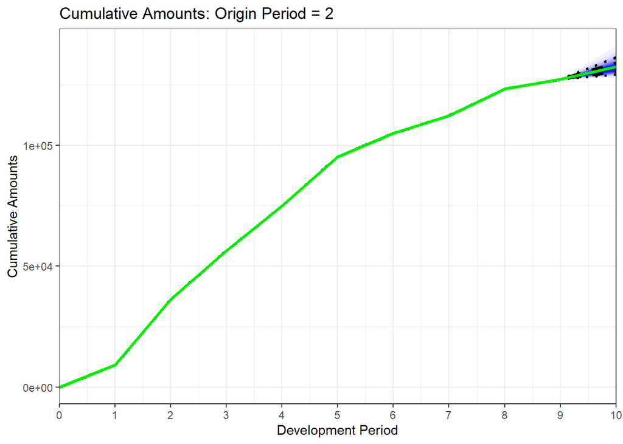

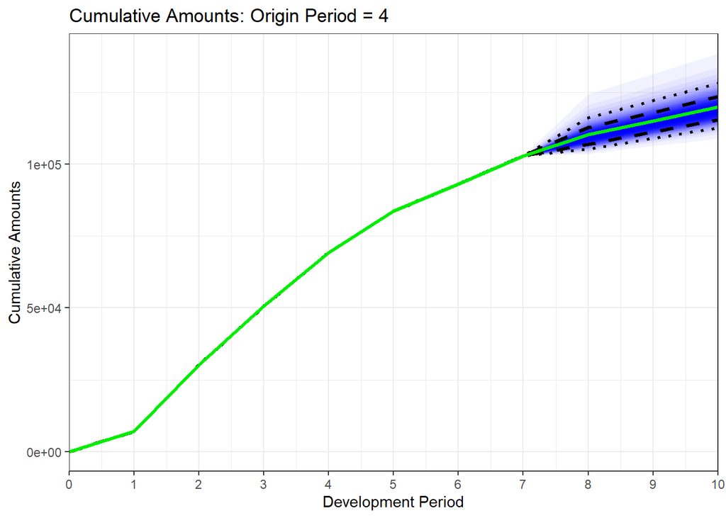

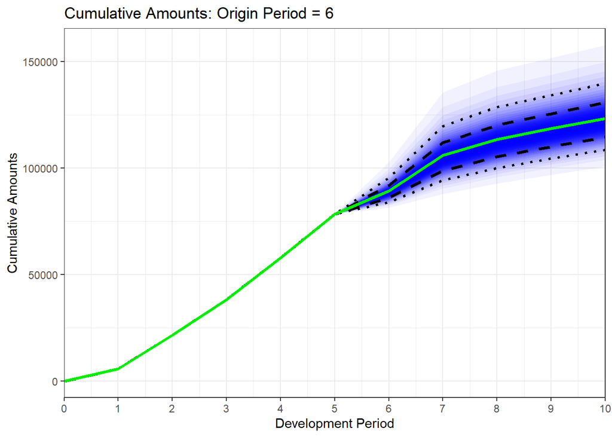

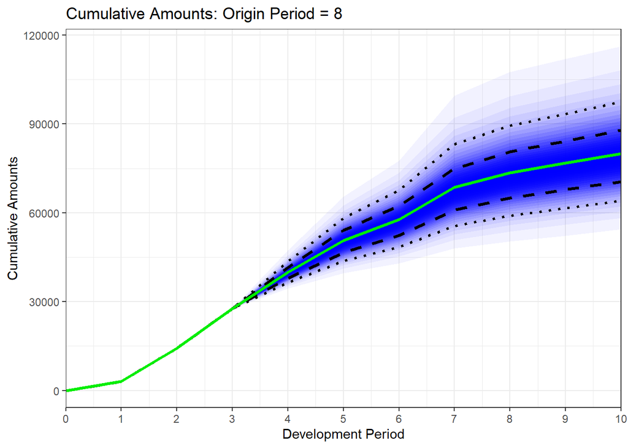

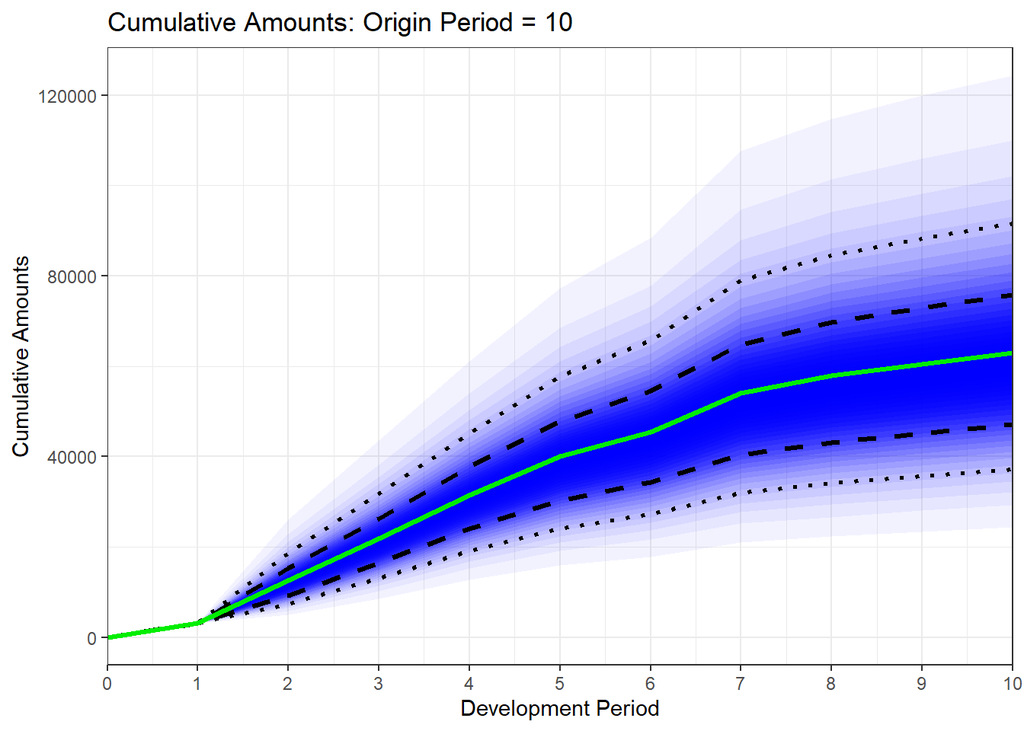

```r
BStrap_Cumulatives <- ODP_Bstrap_Result$Cumulatives

for (yr in seq(2, ncol(BStrap_Cumulatives), by = 2)) {
  print(plotDevelopmentGraph(BStrap_Cumulatives,yr))
}
```

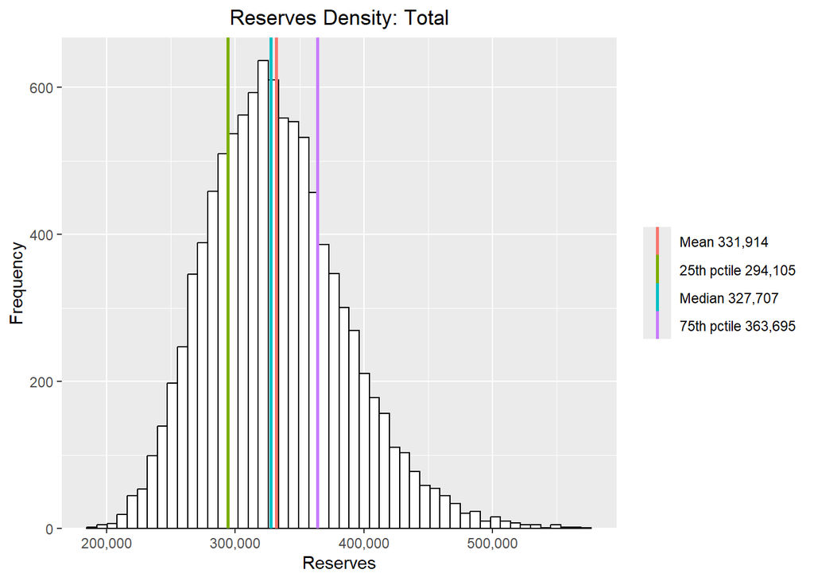

```r
# Histograms - Bootstrap undiscounted reserves
plotHistogram_Total(ODP_Bstrap_Result$TotalReserve)
```

```r
#plotHistogram_by_yr(ODP_Bstrap_Result$Reserves)
```

*Commentary:*

Notice that the reserve development (fan) charts no longer suddenly expand at development period 7 since the values of sqrtScale have a smoother development.

### Step 14: Final selection of which model to use, which ratios to exclude (if any), and whether to apply user-defined variance parameters (Mack’s sigma or the ODP sqrtScale parameters):

After understanding what is driving volatility, and the characteristics and limitations of the models chosen, the actuarial analyst is in a better position to make final selections based on informed judgement.

Where forecasts are required beyond the final development period in the triangle (‘tail’ forecasts), it is common practice to fit curves to the fitted development factors (or to the triangle of link ratios) and extrapolate into the tail. Such practical extensions can be incorporated into the bootstrap process, but are not considered in this example code.

In practice, a further final step might be to scale the distribution of results to target ultimate claims estimates from a “best estimate” reserving analysis.

### Step 15: Scale the results to target ultimate claims if required:

```r
# Test scaling of results to a target ultimate

# Rationale: Bootstrapping usually relies on simple link ratio type models, and the mean of the simulations reflects this.
# However, the "best estimate" reserves from a reserving analysis may use diferent methods, or incorporate elements
# of expert judgement, and may differ from the mean of the simulations.
# Scaling allows us to adjust the simulation results to match a target ultimate, while preserving the distributional characteristics of
# the simulations.

# With Additive scaling, the absolute standard deviation is preserved, but the coefficient of variation changes.
# With Multiplicative scaling, the coefficient of variation is preserved, but the absolute standard deviation changes.

#Unscaled_Results = Mack_Bstrap_Result
Unscaled_Results <- ODP_Bstrap_Result

# Create target ultimate as latest plus 1.1 times the average reserve across all iterations just as an example
# Usually the target ultimates would be derived from a "best estimate" reserving exercise,
# ideally excluding any prudential margin
Target_Ultimates <- Unscaled_Results$Latest + Unscaled_Results$Avg_Reserve * 1.1
num_origin_periods <- length(Unscaled_Results$Avg_Reserve)
#scaling_method <- rep("Additive", num_origin_periods) # Additive for all periods
#scaling_method <- rep("Multiplicative", num_origin_periods) # Multiplicative for all periods
scaling_method <- c(rep("Additive", 5), rep("Multiplicative", num_origin_periods-5)) # Additive for the first five periods, multiplicative thereafter

Scaled_Results_Test <- Scaled_Results(Unscaled_Results, Target_Ultimates, scaling_method)

# Calculate summary statistics for unscaled results
print("Unscaled reserve summary statistics")
```

```
## [1] "Unscaled reserve summary statistics"
```

```r
Unscaled_Stats <- ShowSummaryStats(Unscaled_Results)
```

```
## [1] "Simulation Summary Statistics - Reserves"
##                              OP.1  OP.2  OP.3  OP.4  OP.5   OP.6   OP.7   OP.8   OP.9  OP.10  Total
## Mean                            0  5210 13648 16999 34670  44842  43505  52254  61006  59780 331914
## Standard Deviation              0  2819  4861  6264 11072  12280  11128  13240  17943  21683  53234
## Coefficient of Variation (%)  0.0  54.1  35.6  36.9  31.9   27.4   25.6   25.3   29.4   36.3   16.0
## Minimum                         0   134  1466  2896  7232  12600  12059  16321  12765   6355 188986
## 0.5th Percentile                0   550  4326  5490 13281  20132  20690  24637  25258  18797 219046
## 1st Percentile                  0   765  4946  6023 14476  22047  21992  26802  27533  21160 227048
## 5th Percentile                  0  1514  6835  8400 18940  27139  27106  32745  34928  28925 252733
## 10th Percentile                 0  2035  7973  9785 21604  30072  30064  36385  39746  34060 267494
## 25th Percentile                 0  3165 10137 12518 26775  36089  35698  42870  48309  43994 294104
## 50th Percentile (Median)        0  4746 13067 16143 33194  43535  42566  51036  59028  57440 327687
## 75th Percentile                 0  6735 16508 20553 41225  52248  50273  60164  71661  72725 363684
## 90th Percentile                 0  8971 20147 25289 49555  61189  58051  69739  84838  88504 401680
## 95th Percentile                 0 10527 22521 28561 54823  67039  63312  75831  93233  98924 426336
## 99th Percentile                 0 13895 27532 35727 65954  79255  74452  88623 110511 121271 477786
## 99.5th Percentile               0 15177 29869 38263 70093  82911  78439  93467 118516 129610 500641
## Maximum                         0 19535 39996 58405 93452 113741 101365 117070 146521 173722 573568
```

```r
# Calculate summary statistics for scaled results
print("Scaled reserve summary statistics")
```

```
## [1] "Scaled reserve summary statistics"
```

```r
Scaled_Stats <- ShowSummaryStats(Scaled_Results_Test)
```

```
## [1] "Simulation Summary Statistics - Reserves"
##                              OP.1  OP.2  OP.3  OP.4  OP.5   OP.6   OP.7   OP.8   OP.9  OP.10  Total
## Mean                            0  5731 15013 18699 38137  49326  47856  57479  67107  65758 365105
## Standard Deviation              0  2819  4861  6264 11072  13507  12241  14564  19737  23851  57474
## Coefficient of Variation (%)  0.0  49.2  32.4  33.5  29.0   27.4   25.6   25.3   29.4   36.3   15.7
## Minimum                         0   655  2831  4596 10699  13860  13265  17953  14042   6990 210832
## 0.5th Percentile                0  1071  5691  7190 16748  22145  22759  27100  27784  20676 243920
## 1st Percentile                  0  1286  6311  7723 17943  24252  24192  29482  30286  23276 251785
## 5th Percentile                  0  2034  8200 10100 22407  29853  29816  36020  38420  31817 279787
## 10th Percentile                 0  2556  9338 11485 25071  33080  33070  40023  43720  37466 295348
## 25th Percentile                 0  3686 11501 14218 30242  39698  39267  47157  53140  48394 324243
## 50th Percentile (Median)        0  5267 14432 17843 36661  47888  46823  56140  64931  63184 360662
## 75th Percentile                 0  7256 17873 22253 44692  57473  55301  66181  78827  79997 399713
## 90th Percentile                 0  9492 21512 26989 53022  67307  63856  76713  93322  97355 440836
## 95th Percentile                 0 11048 23886 30261 58290  73743  69644  83415 102556 108816 467173
## 99th Percentile                 0 14416 28896 37427 69421  87181  81897  97485 121562 133398 523641
## 99.5th Percentile               0 15698 31234 39963 73560  91203  86283 102814 130367 142571 546811
## Maximum                         0 20056 41361 60105 96919 125115 111502 128777 161173 191094 626545
```

*Commentary:*

In this fictitious example, target ultimate claims have been calculated as the latest cumulative claims plus the mean reserves from the variability analysis increased by 10%. This is simply to highlight the approach.

With “Additive” scaling, the reserves by origin period for each simulation are simply shifted by the difference between the target reserves and the mean reserves from the bootstrap analysis. This preserves the absolute standard deviation, but changes the coefficient of variation.

With “Multiplicative” scaling, the reserves by origin period for each simulation are simply scaled by the ratio of the target reserves to the mean reserves from the bootstrap analysis. This preserves the coefficient of variation, but changes the absolute standard deviation.

The user can select which scaling approach to use for each origin period. In the example above, Additive scaling has been used for the first 5 origin periods, and Multiplicative scaling has been used for the remaining 5 origin periods.

Note that when comparing the unscaled and scaled summary statistics, the means have changed, but the absolute standard deviation has been retained for the first 5 origin periods and the coefficient of variation has been retained for the remaining 5 origin periods.

If the cash flows are also required, then it is also necessary to scale the cash flows from the bootstrap simulations in an appropriate way.

It should be noted that scaling the bootstrap results to a target ultimate is a pragmatic approach that recognises that a simple stochastic model cannot replicate the nuances that might be included in reserve estimates for other purposes. Ideally, minimal scaling would be applied, and if too much scaling is required, the analyst should stop and investigate further. Obviously “too much” is subjective and is a matter of opinion.

Furthermore, the stochastic models presented here are based on traditional volume-weighted chain ladder models. If the underlying data are such that chain ladder type models would never be used for reserve analysis, they should not be used for reserve variability analysis either; alternative more appropriate models should be used instead.

### Final comments: Common errors and fallacies

It is common to hear actuarial analysts say that they used “THE” bootstrap model in their variability analysis. Bootstrapping is just a statistical procedure that can be applied to well-specified statistical models. When actuarial analysts say they used “THE” bootstrap model, they usually mean the over-dispersed Poisson chain ladder model with constant scale parameter, originally published by England & Verall (1999). England & Verrall subsequently showed how to bootstrap other models, including the over-dispersed Poisson model with non-constant scale parameters and Mack’s model, as shown in the examples above. As such, there is no such thing as “THE” bootstrap model, and it is necessary to be more precise in the description of the model used. In general, when the over-dispersed Poisson model is used, non-constant scale parameters are preferable.

The choice between using the over-dispersed Poisson model and Mack’s model depends on negative observed incremental values and the desirability (or otherwise) of having forecast negative incremental values. Strictly, the ODP model requires chain ladder development factors greater than 1, and since it is a model of incremental values, it will give positive simulated forecast incremental claims. As such, it is less suitable for bootstrapping incurred claims triangles, which often display negative incremental amounts. [Note: the functions for bootstrapping the ODP model in this example code have been adapted to allow negative values in a pragmatic way.]

Mack’s model is a model of cumulative amounts (or, in fact, a model of link ratios), and can be used with negative incremental amounts and when chain ladder development factors are less than 1. Even if observed incremental values are all positive, it is always possible to obtain simulated negative incremental forecast values due the random nature of the simulation process when bootstrapping Mack’s model.

It is sometimes believed that bootstrapping cannot be used with incurred data due to the presence of negative incremental values. Clearly this is not true. With incurred data, if there are development factors less than 1, just bootstrap using Mack’s model assumptions. It should be noted that when using incurred data, the bootstrap procedure gives a distribution of “IBNR+IBNER” (not “reserves”) and also a distribution of ultimates. A distribution of “reserves” can easily be obtained by subtracting the latest paid amounts from each simulated ultimate value. Since the latest paid amounts are constant, the absolute standard deviation of the “reserves” will be the same as the standard deviation of the ultimates (and the standard deviation of the “IBNR+IBNER”). However, if the focus is on the coefficient of variation of the reserves, the standard deviation (of the “IBNR+IBNER” from the incurred analysis) must be divided by the mean reserves to obtain a meaningful number.

A further common fallacy is that parametric bootstrapping involves simulating residuals from a parametric distribution (eg Normal) before inverting to obtain pseudo-data in the bootstrap process. This is not parametric bootstrapping. Parametric bootstrapping involves simulating pseudo-data directly from a parametric distribution, given the mean and variance of the pseudo-data. This is generally preferable to non-parametric bootstrapping, where residuals are resampled before inverting to obtain pseudo-data. Details of non-parametric and parametric bootstrapping can be obtained for Mack’s model and the ODP model by reviewing the relevant example functions.